# Sentiment analysis demo: FARC-Colombia peace talks

Leslie Huang

March 1, 2018

## I used sentiment analysis to model the FARC-Colombia peace talks.

These talks ultimately led to a peace accord that ended a violent, 50-year-long civil war in Colombia. When I started in 2016, the outcome was uncertain. The ups and downs of the talks included rebel attacks on government forces as well as infrastructure such as oil pipelines. Throughout the talks, public statements were frequently made by the office of the Colombian president, the FARC rebel group’s press office, and the peace negotiators.

The challenge was to predict the dynamics of the peace talks – were they going to fall apart? Would they produce a peace treaty – and to understand how each side responded to statements and actions from the other side.

For example, when the government “talks tough,” does this lead to a response from the rebels in kind?

### In this demo, I’ll focus on my results from measuring sentiment. In the next demo, I’ll discuss hidden Markov models and how they can be used to estimate unobserved (aka “hidden”) data.

## Getting started

I wrote my own R library of functions for sentiment analysis and generating graphs for this project. It was designed as a time-saver for me, so it isn’t very flexible e.g. for data in different formats.

```r
devtools::install_github("leslie-huang/faRc-sentiment-analysis-library")
library("faRcSentiment")
```

## What’s the data?

The text data was scraped with Python from the official websites of the FARC guerrilla group, the Colombian president, and the peace negotiators, respectively.

All texts are in the original Spanish, and were parsed and cleaned in Python. Take a look below for the final version:

See below for an example of statements from the government:

[output not shown]

## Sentiment

There are many methods in NLP for measuring the sentiment of texts. I use Linguistic Inquiry and Word Count (LIWC), developed for use in psychology research by James Pennebaker and associates.

LIWC is a dictionary of words with psychological affect, such as negative, positive, happy, sad, etc. I use these to measure the percentage of positive and negative sentiment in each text.

Subsequently, I use loess (“locally weighted scatterplot smoothing”) to smooth the LIWC estimates.

The raw estimates of negative and positive sentiment:

| EmoPos | EmoNeg | date |
| --- | --- | --- |
| 2.3057 | 2.5033 | 2016-05-26 |
| 2.1302 | 2.1302 | 2015-10-12 |
| 0.0000 | 5.5046 | 2016-05-09 |
| 2.8846 | 2.3601 | 2013-12-23 |
| 3.0700 | 1.3588 | 2013-12-23 |
| 2.6316 | 1.4620 | 2013-12-18 |

[output not shown]

Here’s some summary statistics for the data:

|  | FARC | Government | Joint negotiators |
| --- | --- | --- | --- |
| Num. documents | 144.000 | 541.000 | 105.000 |
| Word count | 911.347 | 1905.867 | 594.514 |
| (SD) | 879.284 | 1949.535 | 760.503 |
| Negative mean percent | 1.666 | 0.992 | 0.624 |
| (SD) | 0.857 | 0.656 | 0.596 |
| Positive mean percent | 2.650 | 2.390 | 1.827 |
| (SD) | 1.161 | 0.849 | 1.187 |

## What does sentiment look like over time?

First, we might be interested in overall trends. For example, given that the talks ended with a peace accord, we might expect that positive sentiment increases over time across the board.

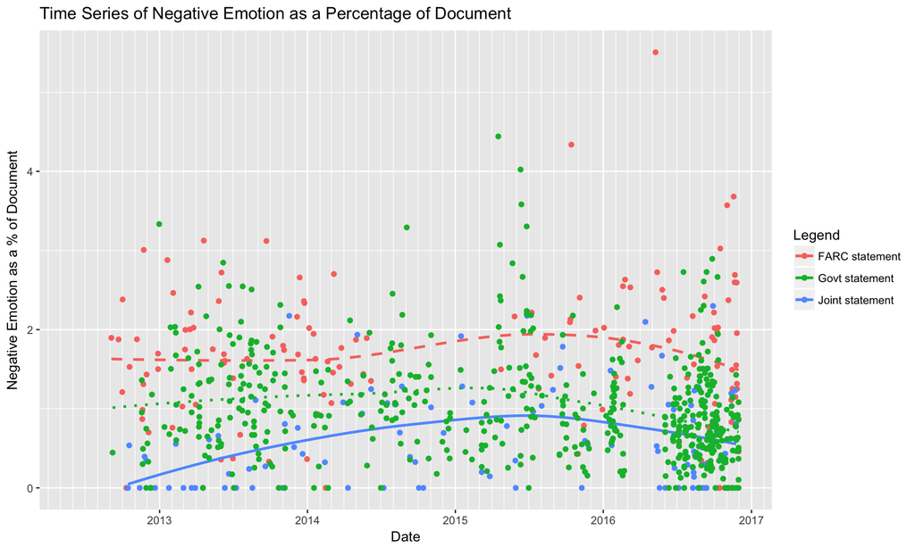

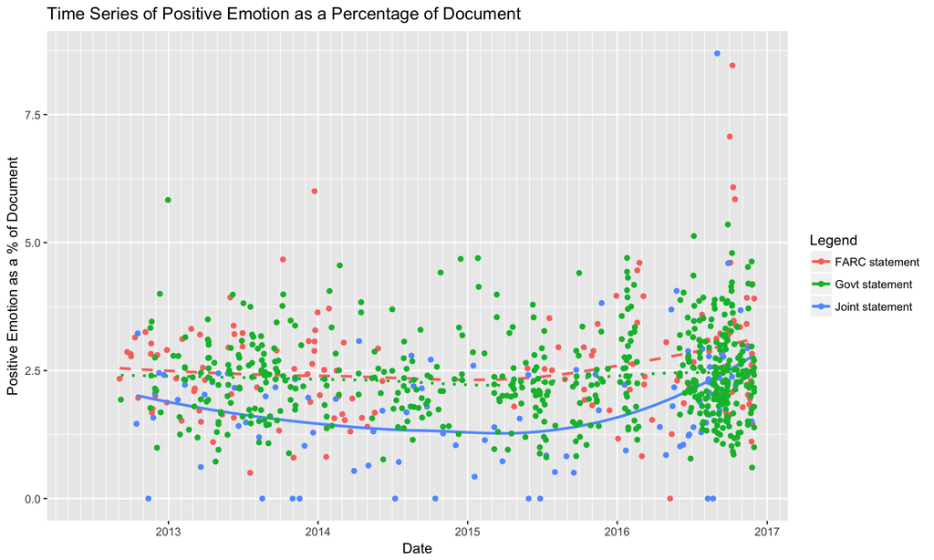

## What else was happening?

The peace talks were punctuated by events, often negative, such as rebel attacks, as well as provisional agreements on sub-parts of the peace agenda.

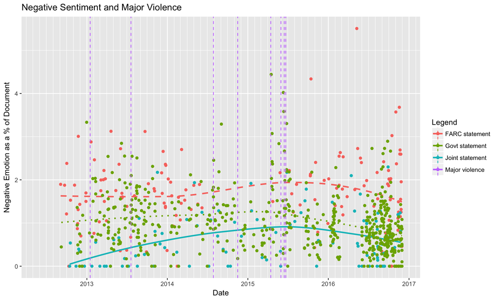

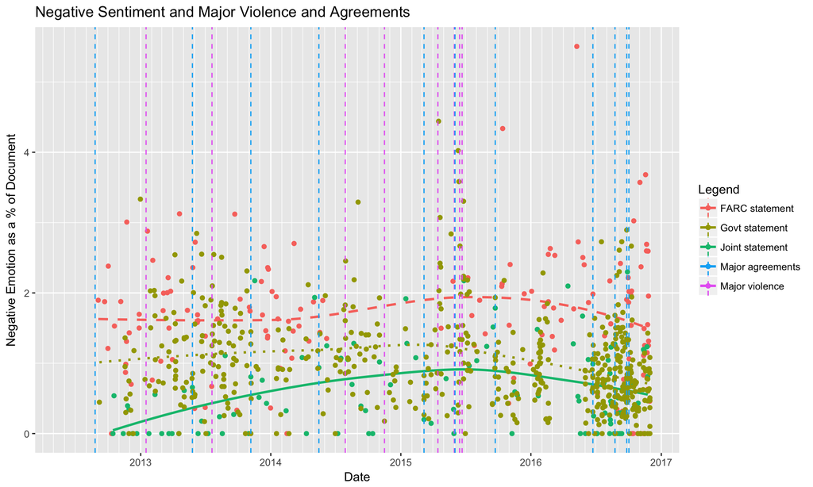

## Sentiment by actor

We might also be interested in examining trends in sentiment by actor. Was the government becoming less positive about the talks as the years passed? (Opposition politicians strongly critized the government for negotiating with terrorists.)

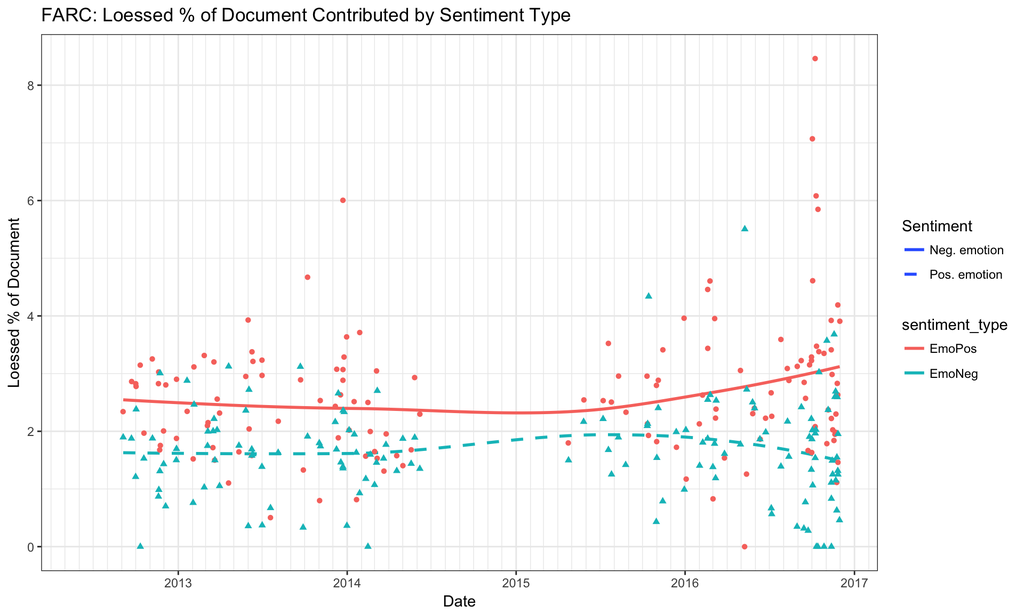

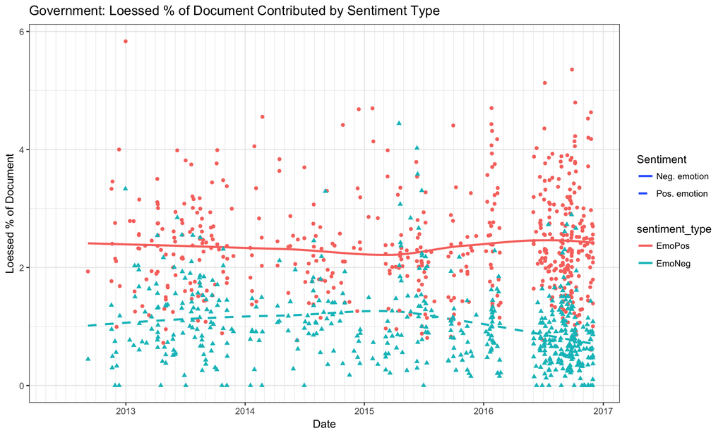

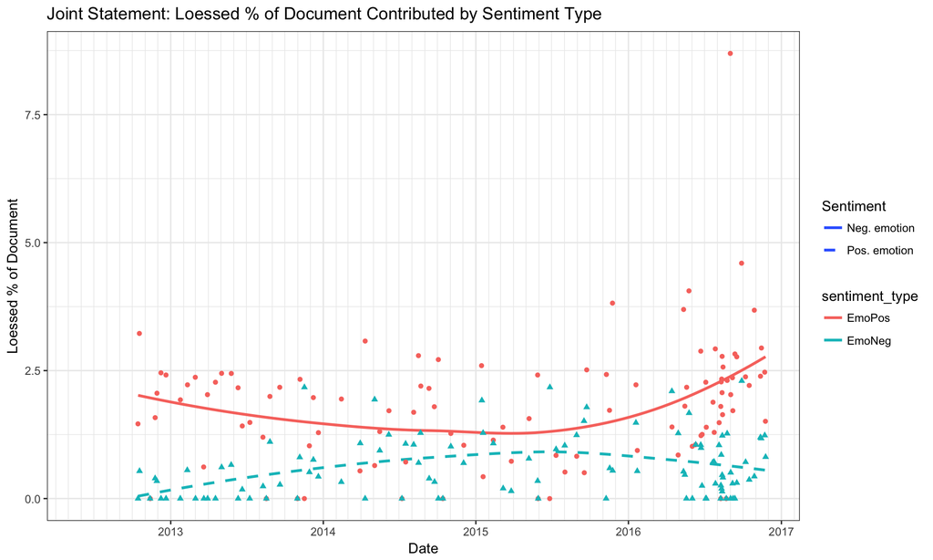

## So how can we use sentiment to predict behavior in negotiations?

Hidden Markov models provide a way for us to leverage observed data, such as sentiment extracted from speech, in order to make predictions about unobserved quantities. The next demo will discuss how to implement HMMs.